# 2017-10-11-PicProject

## How a CNN learned to recognize my face

In this post I built a convlutional neural network and trained it on images of faces of 2 people and then used it predict the person based on unseen images. The process that I followed was:-

- I took a 1000 images each of myself and a friend of mine
- Divided the dataset into train and test set
- Trained a tensorflow based convolutional neural network
- Fed new images to check the prediction probability
- Visualised the activation of the hidden layers.

Rather than writing the code in a sequential manner I wrote the [code](https://github.com/singhsimran39/PicProject.git) in a more object oriented way with classes and methods. In the next few sections I descrbe the important parts of the whole process.

The full code consists of a PicProject class with

- build_model
- cnn_network
- train
- save

functions and

- conv_layer
- get_batches

as helper methods

The constructor of the PicProject class takes in arguments that can be specified from the command line while running the code.

```python
class PicProject(object):

    def __init__(self, sess, batch_size, input_height, input_width, input_channels, fc1_dim, fc2_dim,
                 out_dim, num_maps, epochs, learning_rate, train_path, test_path, model_name):

        self.sess = sess
        self.batch_size = batch_size
        self.input_height = input_height
        self.input_width = input_width
        self.input_channels = input_channels

        self.fc1_dim = fc1_dim
        self.fc2_dim = fc2_dim
        self.out_dim = out_dim
        self.num_maps = num_maps

        self.epochs = epochs
        self.learning_rate = learning_rate

        self.train_path = train_path
        self.test_path = test_path
        self.model_name = model_name

        self.build_model()
```

The architecture of the network is as follows:-

- First convolution layer of filter size 5x5 and a stride of 2 with 16 activation maps using the ReLU activation
- First pooling layer with filter size of 2x2 and stride of 2
- Second convolution layer of filter size 5x5 and a stride of 2 with 32 activation maps using the ReLU activation
- Second pooling layer with filter size of 2x2 and stride of 2
- First fully connected layer with 1000 neurons using the ReLU activation
- Second fully connected layer with 2 neurons with softmax function, this being the last layer

the build_model() method creates the placeholders for the features and teh labels for the data and then creates the network by calling the cnn_network() method. The loss for this network is cross entropy which is also defined in this method. After building the network all the trainable variables are saved and the Saver() method is called to save the full model.

```python
    def build_model(self):

        self.x = tf.placeholder(name='in_pic', shape=[None, self.input_height, self.input_width, self.input_channels],
                                dtype=tf.float32)
        self.y = tf.placeholder(name='real_person', shape=[None, self.out_dim], dtype=tf.float32)

        self.preds, self.logits = self.cnn_network(self.x, self.y)

        self.cross_entropy = tf.reduce_mean(tf.nn.softmax_cross_entropy_with_logits(labels=self.y, logits=self.logits))

        self.t_vars = tf.trainable_variables()
        self.saver = tf.train.Saver()
```

conv_layer() is a helper method that is outside the PicProject() class and creates a convolutional layer from given input values.

This method creates weights and biases variables in the given variable scope of the tensorflow graph such that weights for layer1 of the graph can be accessed as **'h0/h0_W'**

```python
def conv_layer(input_, out_maps, filter_shape=[5, 5], filter_strides=[2, 2], pool_shape=[2, 2],
               pool_strides=[2, 2], name='conv2d'):
    with tf.variable_scope(name):
        weights = tf.get_variable(name=name+'_W', shape=[filter_shape[0], filter_shape[1], input_.shape[3], out_maps],
                                  initializer=tf.truncated_normal_initializer(stddev=0.02))

        biases = tf.get_variable(name=name+'_b', shape=[out_maps],
                                 initializer=tf.truncated_normal_initializer(stddev=0.02))

        conv = tf.nn.conv2d(input=input_, filter=weights, strides=[1, filter_strides[0], filter_strides[1], 1],
                            padding='SAME')
        conv += biases
        conv = tf.nn.relu(conv, name=name+'_conv')

        pool = tf.nn.max_pool(value=conv, ksize=[1, pool_shape[0], pool_shape[1], 1],
                              strides=[1, pool_strides[0], pool_strides[1], 1], padding='SAME', name=name+'_pool')

        return pool
```

The cnn_network() method builds the network by calling the conv_layer() method. After the convolution layer are created the second convolution layer is flattened and then 2 fully connected layers are created along with the respective weights and biases. The last layer uses the softmax function so that the final values ca nbe interpreted as probabilities.

```python
    def cnn_network(self, image, y):

        layer1 = conv_layer(input_=image, out_maps=self.num_maps, name='h0')
        layer2 = conv_layer(input_=layer1, out_maps=self.num_maps*2, name='h1')

        layer2_shape = layer2.get_shape().as_list()
        flattened = tf.reshape(layer2, [-1, layer2_shape[1]*layer2_shape[2]*layer2_shape[3]], name='l2_flat')

        w_fc1 = tf.get_variable(name='w_fc1', shape=[layer2_shape[1]*layer2_shape[2]*layer2_shape[3], self.fc1_dim],
                                initializer=tf.truncated_normal_initializer(stddev=0.02))
        b_fc1 = tf.get_variable(name='b_fc1', shape=[self.fc1_dim], initializer=tf.truncated_normal_initializer(stddev=0.02))

        dense_layer1 = tf.matmul(flattened, w_fc1) + b_fc1
        dense_layer1 = tf.nn.relu(dense_layer1, name='fc1')

        w_fc2 = tf.get_variable(name='w_fc2', shape=[self.fc1_dim, 2], initializer=tf.truncated_normal_initializer(stddev=0.02))
        b_fc2 = tf.get_variable(name='b_fc2', shape=[2], initializer=tf.truncated_normal_initializer(stddev=0.02))

        dense_layer2 = tf.matmul(dense_layer1, w_fc2) + b_fc2
        preds = tf.nn.softmax(dense_layer2, name='fc2')

        return preds, dense_layer2
```

The train() method is the meat of the whole code. In here the get_images function first takes in the path of the and ceates the x (features) and y (labels) values. The label is a 2x1 vector with my images being [0, 1] and my friends images being [1, 0]. My images start with 'S' and the other start with 'V'.

The network uses the Adam optimizer to optimize the loss function and and compares the predictions with the actual y values to get the accuracy. I also subtract the mean from the train and the test images to centre the images around 0. The network is trained for specified number of epochs and the weights are updated after the specified number of batch_size.

```python
    def train(self):

        def get_images(path):
            all_pics = glob.glob(path+'*.jpg')
            all_pics.sort()
            y = np.zeros([len(all_pics), self.out_dim])
            i = 0

            for pic in all_pics:
                sw = pic.split(path)[1]
                if sw.startswith('S'):
                    y[i, 1] = 1
                else:
                    y[i, 0] = 1
                i += 1

            x = np.array([misc.imread(pic) for pic in all_pics])
            x = np.array(x).astype(np.float32)
            y = np.array(y).astype(np.float32)

            return x, y

        optim = tf.train.AdamOptimizer(learning_rate=self.learning_rate).minimize(self.cross_entropy,
                                                                                  var_list=self.t_vars)
        correct = tf.equal(tf.argmax(self.y, 1), tf.argmax(self.preds, 1))
        accuracy = tf.reduce_mean(tf.cast(correct, tf.float32))

        tf.global_variables_initializer().run()

        train_x, train_y = get_images(self.train_path)
        test_x, test_y = get_images(self.test_path)

        train_x -= np.mean(train_x)
        test_x -= np.mean(test_x)

        fulldata = Dataset(train_x, train_y)

        num_batches = get_batches(self.batch_size, train_x.shape[0])

        for epoch in range(self.epochs):
            avg_cost = 0

            for i in range(int(num_batches)):
                batch_x, batch_y = fulldata.next_batch(self.batch_size)
                _, c = self.sess.run([optim, self.cross_entropy], feed_dict={self.x:batch_x, self.y:batch_y})
                avg_cost += c / num_batches

            _, train_acc = self.sess.run([optim, accuracy], feed_dict={self.x:train_x, self.y:train_y})
            _, test_loss, test_acc = self.sess.run([optim, self.cross_entropy, accuracy],
                                                   feed_dict={self.x:test_x, self.y:test_y})
            print('Epoch:', (epoch+1), 'TrainAccuracy:', '{:.4f}'.format(train_acc), 'TrainLoss:',
                  '{:.6f}'.format(avg_cost), 'TestAccuracy:', '{:.4f}'.format(test_acc),
                  'TestLoss:', '{:.6f}'.format(test_loss))

        self.save()
```

The save() function uses the saver object created in the build_model() method to save the trained model.

```python
    def save(self):
        self.saver.save(self.sess, self.model_name)
```

Now comes the interesting part of the project the visualisation of the hidden layers when I feed in my image to the trained network.

The shape of the test image is [1, 200, 200, 3], to visualise the network first let us see the input images. The below shows the input image

[figure not shown]

The First convolutional layer shows the image from the 16 different activation maps and we can see that the network at this layer absorbs the high level features of an image. Moreover in some maps the dark black beard and the dark coloured turban are specifically highlighted by the activations.

```
INFO:tensorflow:Restoring parameters from picProject
```

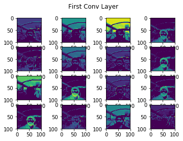

```python
with tf.Session() as sess:
    saver = tf.train.import_meta_graph('picProject.meta')
    saver.restore(sess, 'picProject')

    first_conv_layer, first_pool_layer = sess.run(['h0/h0_conv:0', 'h0/h0_pool:0'], feed_dict={'in_pic:0':pics})

for i in range(0, 16):
    plt.subplot(4, 4, (i+1))
    plt.imshow(misc.imrotate(first_conv_layer[0,:,:,i], -90))
plt.suptitle('First Conv Layer')
plt.show()
```

The first pooling layer is again similar but has its dimensions reduced.

```
INFO:tensorflow:Restoring parameters from picProject
```

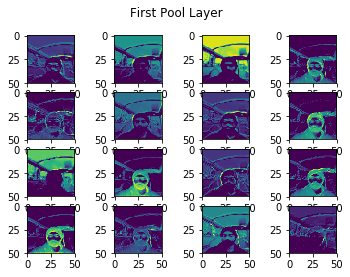

```python
with tf.Session() as sess:
    saver = tf.train.import_meta_graph('picProject.meta')
    saver.restore(sess, 'picProject')

    first_conv_layer, first_pool_layer = sess.run(['h0/h0_conv:0', 'h0/h0_pool:0'], feed_dict={'in_pic:0':pics})

for i in range(0, 16):
    plt.subplot(4, 4, (i+1))
    plt.imshow(misc.imrotate(first_pool_layer[0,:,:,i], -90))
plt.suptitle('First Pool Layer')
plt.show()
```

The second cpnvulutional and pooling layers are less recognizable and learn the finer details of the image.

```
INFO:tensorflow:Restoring parameters from picProject
```

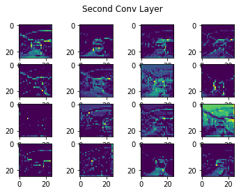

```python
with tf.Session() as sess:
    saver = tf.train.import_meta_graph('picProject.meta')
    saver.restore(sess, 'picProject')

    first_conv_layer, first_pool_layer = sess.run(['h1/h1_conv:0', 'h1/h1_pool:0'], feed_dict={'in_pic:0':pics})

for i in range(0, 16):
    plt.subplot(4, 4, (i+1))
    plt.imshow(misc.imrotate(first_conv_layer[0,:,:,i], -90))
plt.suptitle('Second Conv Layer')
plt.show()
```

```
INFO:tensorflow:Restoring parameters from picProject
```

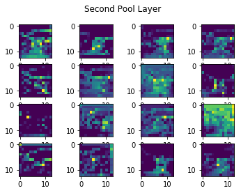

```python
with tf.Session() as sess:
    saver = tf.train.import_meta_graph('picProject.meta')
    saver.restore(sess, 'picProject')

    first_conv_layer, first_pool_layer = sess.run(['h1/h1_conv:0', 'h1/h1_pool:0'], feed_dict={'in_pic:0':pics})

for i in range(0, 16):
    plt.subplot(4, 4, (i+1))
    plt.imshow(misc.imrotate(first_pool_layer[0,:,:,i], -90))
plt.suptitle('Second Pool Layer')
plt.show()
```

The full code for this project is available [here](https://github.com/singhsimran39/PicProject.git)